# Finance & Stock Market Analysis – Investor Behavior & Decision Insights

## 🟦 Title Page

**Project Title:** Finance & Stock Market Analysis – Investor Behavior & Decision Insights

**Author:** Rahul Mahakal

**Domain:** Finance & Investment Analytics

**Tools & Technologies Used:**

- Python
- Pandas & NumPy
- Matplotlib & Seaborn
- Jupyter Notebook
- Modular Python Architecture
- OS-independent file handling using `pathlib`

## 🟦 Executive Summary

This project analyzes investor demographic data and financial behavior to understand investment preferences, risk appetite, monitoring patterns, and decision-making drivers. By combining descriptive statistics with advanced behavioral visualizations, the study provides actionable insights into how different investor segments choose financial instruments and manage their portfolios.

## 🟦 Introduction

### Business Problem

Individual investors exhibit diverse financial behaviors influenced by age, risk tolerance, investment objectives, and monitoring habits. Understanding these patterns is essential for financial institutions, advisors, and policymakers to design targeted products and improve investor outcomes.

### Objectives

- Analyze preferred investment avenues
- Study equity market participation
- Understand investment objectives and duration preferences
- Examine risk appetite and monitoring behavior
- Identify correlations among financial instruments
- Generate data-driven financial recommendations

## 🟦 Dataset Description

### Dataset Overview

The dataset contains survey-based investment behavior data, capturing demographic information, preferred investment avenues, risk factors, objectives, and monitoring habits.

### Key Columns

- `gender`, `age` – Demographics
- `Investment_Avenues` – Primary investment choice
- `Equity_Market`, `Mutual_Funds`, `Fixed_Deposits`, `Gold`, `PPF` – Instrument preferences
- `Objective` – Investment objective
- `Duration` – Investment horizon
- `Factor` – Risk factor
- `Invest_Monitor` – Portfolio monitoring frequency
- `What are your savings objectives?` – Savings motivation
- `Reason_Equity`, `Reason_Mutual` – Behavioral motivation

### 🟦 Data Source

Finance behavior dataset used for analytical and portfolio development purposes.

### Dataset Size

- Records: Based on CSV file
- Data Type: Predominantly categorical with demographic attributes
- Missing Values: Validated during preprocessing

## 🟦 Methodology

### Analytics Pipeline

1. Data ingestion and validation
2. Feature engineering (age groups, equity participation)
3. Exploratory data analysis
4. Behavioral pattern analysis
5. Statistical summarization
6. Insight and recommendation generation

### Tools & Techniques

- GroupBy and Crosstab analysis
- Categorical distribution analysis
- Behavioral finance visualization techniques
- Correlation analysis between financial instruments

### 🟦 DATA LOADING & VALIDATION

```python
import pandas as pd
import numpy as np
import matplotlib.pyplot as plt
import seaborn as sns
import sys
from pathlib import Path

sns.set_theme(style="whitegrid")

BASE_DIR = Path.cwd().parent
DATA_DIR = BASE_DIR / "datasets"

# Detect project root (Multi-Domain-Data-Analysis-Portfolio)
PROJECT_ROOT = Path.cwd().parents[0]

# Add to PYTHONPATH
sys.path.insert(0, str(PROJECT_ROOT))

print("=" * 95)
print("Project root added:", PROJECT_ROOT)
print("=" * 95)
print("src visible:", (PROJECT_ROOT / "src").exists())
print("=" * 95)

df = pd.read_csv(DATA_DIR / "Finance_data.csv")
df.head()
```

```
===============================================================================================
Project root added: C:\Users\mahakal.r\PycharmProjects\Multi-Domain-Data-Analysis-Portfolio
===============================================================================================
src visible: True
===============================================================================================
```

|  | gender | age | Investment_Avenues | Mutual_Funds | Equity_Market | Debentures | Government_Bonds | Fixed_Deposits | PPF | Gold | ... | Duration | Invest_Monitor | Expect | Avenue | What are your savings objectives? | Reason_Equity | Reason_Mutual | Reason_Bonds | Reason_FD | Source |
| --- | --- | --- | --- | --- | --- | --- | --- | --- | --- | --- | --- | --- | --- | --- | --- | --- | --- | --- | --- | --- | --- |
| 0 | Female | 34 | Yes | 1 | 2 | 5 | 3 | 7 | 6 | 4 | ... | 1-3 years | Monthly | 20%-30% | Mutual Fund | Retirement Plan | Capital Appreciation | Better Returns | Safe Investment | Fixed Returns | Newspapers and Magazines |
| 1 | Female | 23 | Yes | 4 | 3 | 2 | 1 | 5 | 6 | 7 | ... | More than 5 years | Weekly | 20%-30% | Mutual Fund | Health Care | Dividend | Better Returns | Safe Investment | High Interest Rates | Financial Consultants |
| 2 | Male | 30 | Yes | 3 | 6 | 4 | 2 | 5 | 1 | 7 | ... | 3-5 years | Daily | 20%-30% | Equity | Retirement Plan | Capital Appreciation | Tax Benefits | Assured Returns | Fixed Returns | Television |
| 3 | Male | 22 | Yes | 2 | 1 | 3 | 7 | 6 | 4 | 5 | ... | Less than 1 year | Daily | 10%-20% | Equity | Retirement Plan | Dividend | Fund Diversification | Tax Incentives | High Interest Rates | Internet |
| 4 | Female | 24 | No | 2 | 1 | 3 | 6 | 4 | 5 | 7 | ... | Less than 1 year | Daily | 20%-30% | Equity | Retirement Plan | Capital Appreciation | Better Returns | Safe Investment | Risk Free | Internet |

5 rows × 24 columns

```python
df.columns
```

```
Index(['gender', 'age', 'Investment_Avenues', 'Mutual_Funds', 'Equity_Market',
       'Debentures', 'Government_Bonds', 'Fixed_Deposits', 'PPF', 'Gold',
       'Stock_Marktet', 'Factor', 'Objective', 'Purpose', 'Duration',
       'Invest_Monitor', 'Expect', 'Avenue',
       'What are your savings objectives?', 'Reason_Equity', 'Reason_Mutual',
       'Reason_Bonds', 'Reason_FD', 'Source'],
      dtype='object')
```

```python
df.info()
```

```
<class 'pandas.core.frame.DataFrame'>
RangeIndex: 40 entries, 0 to 39
Data columns (total 24 columns):
 #   Column                             Non-Null Count  Dtype
---  ------                             --------------  -----
 0   gender                             40 non-null     object
 1   age                                40 non-null     int64
 2   Investment_Avenues                 40 non-null     object
 3   Mutual_Funds                       40 non-null     int64
 4   Equity_Market                      40 non-null     int64
 5   Debentures                         40 non-null     int64
 6   Government_Bonds                   40 non-null     int64
 7   Fixed_Deposits                     40 non-null     int64
 8   PPF                                40 non-null     int64
 9   Gold                               40 non-null     int64
```

[output cut: 16 more lines]

```python
df.isnull().sum()
```

```
gender                               0
age                                  0
Investment_Avenues                   0
Mutual_Funds                         0
Equity_Market                        0
Debentures                           0
Government_Bonds                     0
Fixed_Deposits                       0
PPF                                  0
Gold                                 0
Stock_Marktet                        0
Factor                               0
Objective                            0
Purpose                              0
Duration                             0
Invest_Monitor                       0
Expect                               0
Avenue                               0
What are your savings objectives?    0
Reason_Equity                        0
Reason_Mutual                        0
Reason_Bonds                         0
Reason_FD                            0
Source                               0
dtype: int64
```

### 🟦 SAFE FEATURE ENGINEERING

```python
# Age bands (financially meaningful)
df["AGE_GROUP"] = pd.cut(
    df["age"],
    bins=[18, 25, 35, 45, 60, 100],
    labels=["18–25", "26–35", "36–45", "46–60", "60+"]
)

# Binary equity preference
df["EQUITY_INVESTOR"] = df["Equity_Market"].apply(
    lambda x: 1 if str(x).lower() == "yes" else 0
)
```

## 🟦 Exploratory Data Analysis (EDA)

##### 1️⃣ Preferred Investment Avenues

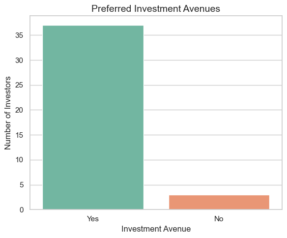

```python
plt.figure(figsize=(6, 5))

sns.countplot(
    data=df,
    x="Investment_Avenues",
    hue="Investment_Avenues",     # REQUIRED
    palette="Set2",
    legend=False
)

plt.title("Preferred Investment Avenues", fontsize=14)
plt.xlabel("Investment Avenue")
plt.ylabel("Number of Investors")
plt.xticks(rotation=0)
plt.tight_layout()
plt.show()
```

##### 2️⃣ Equity Market Participation

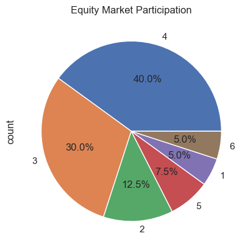

```python
df["Equity_Market"].value_counts().plot(kind="pie", autopct="%1.1f%%")
plt.title("Equity Market Participation")
plt.show()
```

##### 3️⃣ Investment Objective Distribution

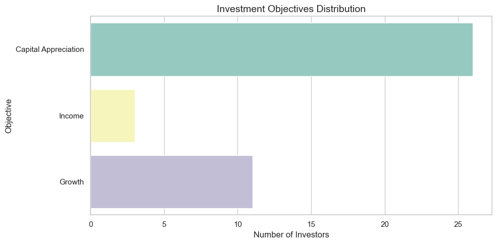

```python
plt.figure(figsize=(10, 5))

sns.countplot(
    data=df,
    y="Objective",
    hue="Objective",
    palette="Set3",
    legend=False
)

plt.title("Investment Objectives Distribution", fontsize=14)
plt.xlabel("Number of Investors")
plt.ylabel("Objective")
plt.tight_layout()
plt.show()
```

##### 4️⃣ Risk Factor vs Investment Avenue

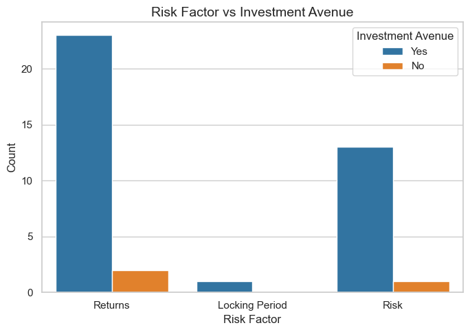

```python
plt.figure(figsize=(7, 5))

sns.countplot(
    data=df,
    x="Factor",
    hue="Investment_Avenues",
    palette="tab10"
)

plt.title("Risk Factor vs Investment Avenue", fontsize=14)
plt.xlabel("Risk Factor")
plt.ylabel("Count")
plt.legend(title="Investment Avenue")
plt.tight_layout()
plt.show()
```

**Caption: -** Examines how risk tolerance influences investment choices.

##### 5️⃣ Duration vs Investment Type

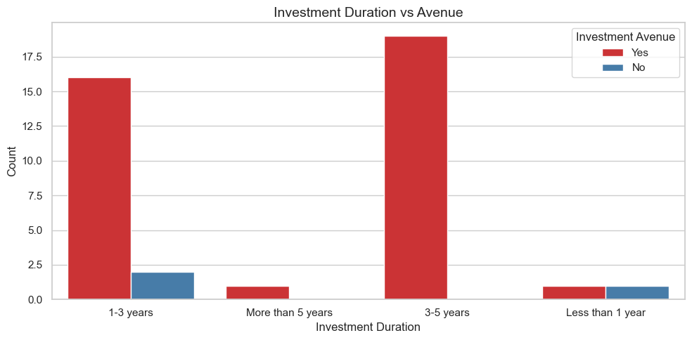

```python
plt.figure(figsize=(10, 5))

sns.countplot(
    data=df,
    x="Duration",
    hue="Investment_Avenues",
    palette="Set1"
)

plt.title("Investment Duration vs Avenue", fontsize=14)
plt.xlabel("Investment Duration")
plt.ylabel("Count")
plt.legend(title="Investment Avenue")
plt.tight_layout()
plt.show()
```

**Caption: -** Analyzes the relationship between investment horizon and instrument selection.

##### 6️⃣ Age vs Investment Avenue (Behavioral Pattern)

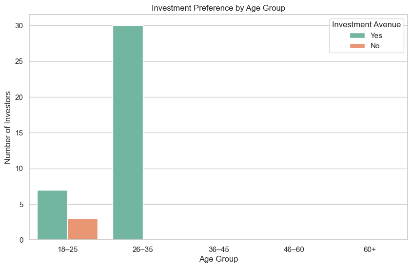

```python
plt.figure(figsize=(10, 6))
sns.countplot(
    data=df,
    x="AGE_GROUP",
    hue="Investment_Avenues",
    palette="Set2"
)
plt.title("Investment Preference by Age Group")
plt.xlabel("Age Group")
plt.ylabel("Number of Investors")
plt.legend(title="Investment Avenue")
plt.show()
```

**Caption: -** Reveals how investment preferences vary across age groups.

##### 7️⃣ Savings Objective vs Investment Avenue (Decision Driver)

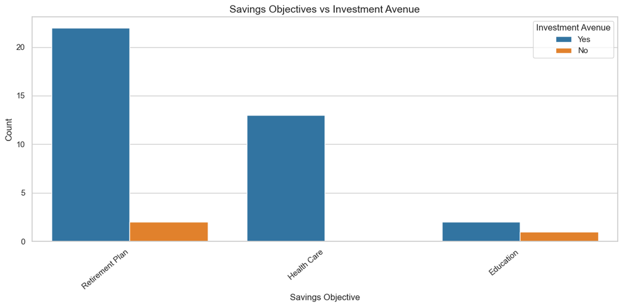

```python
plt.figure(figsize=(12, 6))

sns.countplot(
    data=df,
    x="What are your savings objectives?",
    hue="Investment_Avenues",
    palette="tab10"
)

plt.title("Savings Objectives vs Investment Avenue", fontsize=14)
plt.xlabel("Savings Objective")
plt.ylabel("Count")
plt.xticks(rotation=40, ha="right")
plt.legend(title="Investment Avenue")
plt.tight_layout()
plt.show()
```

**Caption: -** Explores how savings goals drive financial decisions.

##### 8️⃣ Reasons for Equity vs Mutual Funds (Motivation Analysis)

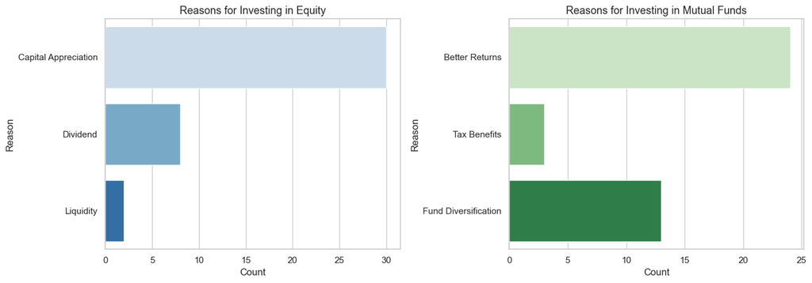

```python
fig, axes = plt.subplots(1, 2, figsize=(14, 5))

# Equity Reasons
sns.countplot(
    data=df,
    y="Reason_Equity",
    hue="Reason_Equity",     # REQUIRED for palette
    palette="Blues",
    legend=False,
    ax=axes[0]
)
axes[0].set_title("Reasons for Investing in Equity", fontsize=13)
axes[0].set_xlabel("Count")
axes[0].set_ylabel("Reason")

# Mutual Fund Reasons
sns.countplot(
    data=df,
    y="Reason_Mutual",
    hue="Reason_Mutual",     # REQUIRED for palette
    palette="Greens",
    legend=False,
    ax=axes[1]
)
axes[1].set_title("Reasons for Investing in Mutual Funds", fontsize=13)
axes[1].set_xlabel("Count")
axes[1].set_ylabel("Reason")

plt.tight_layout()
plt.show()
```

**Caption: -** Provides insight into motivational factors behind investment choices.

##### 9️⃣ Investment Monitoring vs Avenue (Behavior Maturity)

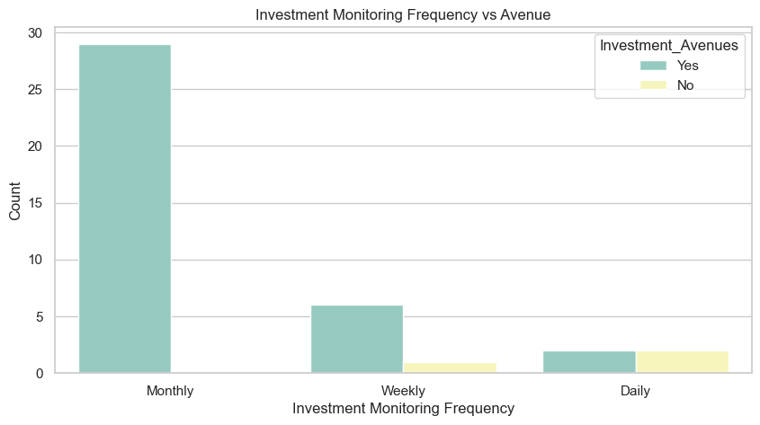

```python
plt.figure(figsize=(10, 5))
sns.countplot(
    data=df,
    x="Invest_Monitor",
    hue="Investment_Avenues",
    palette="Set3"
)
plt.title("Investment Monitoring Frequency vs Avenue")
plt.xlabel("Investment Monitoring Frequency")
plt.ylabel("Count")
plt.show()
```

**Caption: -** Assesses investor maturity through portfolio monitoring behavior.

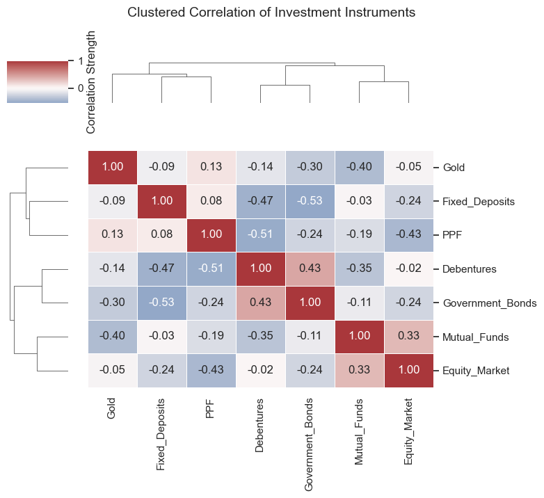

```python
binary_cols = [
    "Mutual_Funds", "Equity_Market", "Debentures",
    "Government_Bonds", "Fixed_Deposits", "PPF", "Gold"
]

corr = df[binary_cols].corr()

sns.clustermap(
    corr,
    cmap="vlag",
    center=0,
    annot=True,
    fmt=".2f",
    linewidths=0.5,
    figsize=(8, 7),
    dendrogram_ratio=(.15, .15),
    cbar_kws={"label": "Correlation Strength"}
)

plt.suptitle(
    "Clustered Correlation of Investment Instruments",
    fontsize=14,
    y=1.02
)
plt.tight_layout()
plt.show()
```

**Caption: -** Identifies relationships and diversification patterns among financial instruments.

### 🟦 Statistical Analysis

```python
df.groupby("AGE_GROUP", observed=True)["EQUITY_INVESTOR"].mean()
```

```
AGE_GROUP
18–25    0.0
26–35    0.0
Name: EQUITY_INVESTOR, dtype: float64
```

```python
df.groupby("gender")["EQUITY_INVESTOR"].mean()
```

```
gender
Female    0.0
Male      0.0
Name: EQUITY_INVESTOR, dtype: float64
```

```python
pd.crosstab(df["Factor"], df["Investment_Avenues"])
```

| Investment_Avenues Factor | No | Yes |
| --- | --- | --- |
| Locking Period | 0 | 1 |
| Returns | 2 | 23 |
| Risk | 1 | 13 |

```python
from src.finance_stock_market_analysis.visualization import *

output_dir = Path("../visualizations/finance")

plot_preferred_investment_avenues(df, output_dir)
plot_equity_market_participation(df, output_dir)
plot_investment_objective_distribution(df, output_dir)
plot_risk_factor_vs_avenue(df, output_dir)
plot_duration_vs_avenue(df, output_dir)
plot_age_vs_avenue(df, output_dir)
plot_savings_objective_vs_avenue(df, output_dir)
plot_reasons_equity_vs_mutual(df, output_dir)
plot_investment_monitoring_vs_avenue(df, output_dir)
plot_clustered_correlation_heatmap(df, output_dir)

print("✅ All the visualizations exported successfully")
```

```
✅ All the visualizations exported successfully
```

## 🟦 Recommendations

1. Promote diversified portfolios across age groups
2. Encourage long-term, goal-based investment planning
3. Educate conservative investors on risk-adjusted returns
4. Support regular portfolio monitoring for better outcomes
5. Align financial products with investor risk profiles

## 🟦 Conclusion & Future Scope

### Conclusion

This project demonstrates how investor behavior data can be transformed into meaningful financial intelligence. Through structured analysis and advanced visualizations, the study highlights key behavioral patterns that can support better financial decision-making and product design.

### Future Scope

- Predictive modeling of investor behavior
- Risk-return optimization analysis
- Time-series analysis of investment evolution
- Integration with real-time market data

**End of Report**